# U.S. Warehouse Industry and Occupation Indicators

2/4/2020

# Classifying warehouse work

There are many types of jobs within warehouses and warehouses can be found in many industries. This makes it challenging to create a snapshot of warehouse work in the U.S. Should we be looking at occupation or industry statistics?

If we look at occupation statistics, we are going to pick up those who perform typical warehouse roles, like stocking, in non-warehouse establishments, like grocery stores. If we look at industry statistics, namely, warehousing, we are going to pick up jobs that aren’t usually carried out in warehouses, like sales, and we are going to miss those who work in warehouses that have owners not classified as part of the industry. Amazon is the most notable example of the second problem; it is classified as belonging to the electronic shopping industry.

Several studies provide estimates of who works in warehouses, but they do not go into detail about their classification method.

I propose that we look at the intersection of occupation and industry. In particular, we should look at the most common jobs within the warehousing industry. We should then compare these jobs to what we have observed in our visits to warehouses. Finally, we should look for other industries in which these jobs are common.

The CPS will allow us to look at the industry-occupation intersection for individual workers, over time, so this is where I get most of the data used below. Specifically, I use the December survey. (In the future I might consider using all months and averaging.) A word of caution, however: when I have looked at industry-level statistics, I have found that the CPS tends to show fewer jobs in warehousing than other BLS datasets, including the CES and QCEW, which are generally preferred for industry employment statistics. I would interpret the estimates that follow then as lower bounds.

### Most common occupations in the warehousing and storage industry (NAICS 493) in 2020

We can start by looking in the most obvious place: the most common jobs in the warehousing industry. The below table aligns with what we might expect, given our warehouse visits.

| Occupation | Total Employment |
| --- | --- |
| Laborers and Freight, Stock, and Material Movers, Hand | 185,128 |
| Packers and Packagers, Hand | 123,791 |
| Stock Clerks and Order Fillers | 93,056 |
| Industrial Truck and Tractor Operators | 87,814 |
| Shipping, Receiving, and Traffic Clerks | 75,549 |
| Managers, nec (including Postmasters) | 61,982 |
| Transportation, Storage, and Distribution Managers | 41,286 |
| Inspectors, Testers, Sorters, Samplers, and Weighers | 33,869 |
| Other production workers including semiconductor processors and cooling and freezing equipment operators | 23,779 |
| Driver/Sales Workers and Truck Drivers | 22,837 |

Source: IPUMS CPS. This does not include self-employed, government, or agricultural workers.

### Selection of occupations

From the above table, we can select occupations to be used in the subsequent analyses. The following occupational SOC codes are included (Census code in italics; pre-2011 SOC codes in parentheses):

- **53-7062**: Laborers and Freight, Stock, and Material Movers, Hand, *9620*
- **53-7064**: Packers and Packagers, Hand, *9640*
- **53-7065**: Stockers and Order Fillers, *5620* (43-5081)
- **53-7051**: Industrial Truck and Tractor Operators, *9600*
- **43-5071**: Shipping, Receiving, and Traffic Clerks, *5610*
- **11-3071**: Transportation, Storage, and Distribution Managers, *0160*

This occupational set is comparable but not identical to other studies of warehouse work, including Gutelius and Theodore (2019) and De Lara (2013).

### Other industries with lots of warehouse jobs in 2020

The next question is what other industries should be included? The below tables show industries that have lots of the jobs identified above.

Largest number of workers in most common warehousing occupations

| Industry | Total Employment | Warehousing Occupations Employment | Warehousing Occupations as Share of Total Employment |
| --- | --- | --- | --- |
| Supermarkets and other grocery (except convenience) stores | 2,586,038 | 824,932 | 0.32 |
| General merchandise stores, including warehouse clubs and supercenters | 2,145,218 | 690,364 | 0.32 |
| Warehousing and storage | 918,680 | 627,320 | 0.68 |
| Couriers and messengers | 1,314,726 | 385,930 | 0.29 |
| Construction | 7,875,345 | 384,364 | 0.05 |
| Electronic shopping and mail-order houses | 881,767 | 312,460 | 0.35 |
| Computer systems design and related services | 3,680,221 | 233,529 | 0.06 |
| Building material and supplies dealers | 1,092,227 | 208,196 | 0.19 |
| Groceries and related products, merchant wholesalers | 734,984 | 175,445 | 0.24 |
| Motor vehicles and motor vehicle equipment manufacturing | 1,332,940 | 160,013 | 0.12 |

Largest share of workers in most common warehousing occupations

| Industry | Total Employment | Warehousing Occupations Employment | Warehousing Occupations as Share of Total Employment |
| --- | --- | --- | --- |
| Warehousing and storage | 918,680 | 627,320 | 0.68 |
| Pottery, ceramics, and plumbing fixture manufacturing | 12,170 | 7,399 | 0.61 |
| Not specified metal industries | 29,864 | 13,968 | 0.47 |
| Management of companies and enterprises | 81,112 | 28,819 | 0.36 |
| Electronic shopping and mail-order houses | 881,767 | 312,460 | 0.35 |
| Farm supplies, merchant wholesalers | 58,068 | 20,093 | 0.35 |
| Paint, coating, and adhesives manufacturing | 50,304 | 17,307 | 0.34 |
| General merchandise stores, including warehouse clubs and supercenters | 2,145,218 | 690,364 | 0.32 |
| Supermarkets and other grocery (except convenience) stores | 2,586,038 | 824,932 | 0.32 |
| Lumber and other construction materials, merchant wholesalers | 155,293 | 48,862 | 0.31 |

Source: IPUMS CPS. This does not include self-employed, government, or agricultural workers.

### Selection of industries

The following NAICS codes are thus included in what follows:

- **493**: Warehousing and Storage
- **4541**: Electronic Shopping and Mail-Order Houses

## Snapshot of Warehouse employment

### Trend in occupational growth vs U.S. overall

With these occupations and industries in mind, we can look at the intersection for trends in warehouse employment.

As of 2020, there were 472,282 people working in warehouse jobs in the U.S. This is up from 161,325 in 2009, after the recession ended.

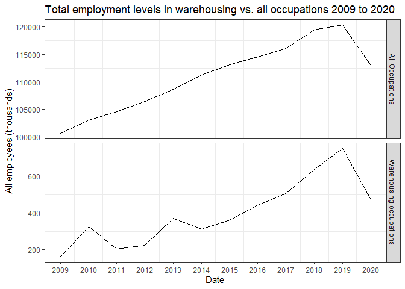

Source: IPUMS CPS. This does not include self-employed, government, or agricultural workers.

### Annual change in warehouse occupation employment

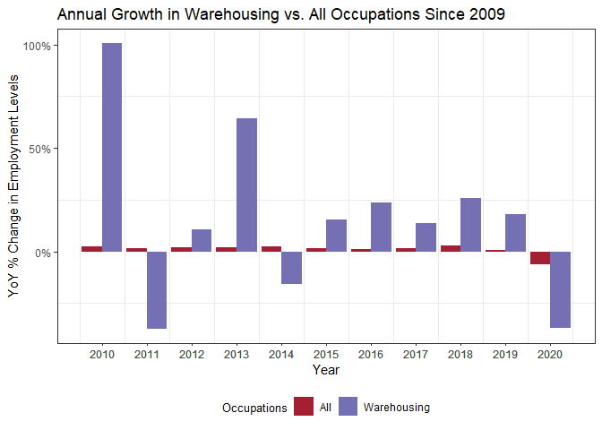

Source: IPUMS CPS. This does not include self-employed, government, or agricultural workers.

### Share of temp workers

A question that comes up is whether these numbers are overlooking temp workers. Do temp workers make up a sizable share of the warehouse workforce?

In 2020, there were 143,112 people employed in the temp industry (NAICS 5613) within the common warehousing occupations identified above. If we add this number to the above total, 615,394 work in warehousing; 23.26% of them are temps. In what follows, I exclude the temp industry because it is tricky to be sure who works where, but we should keep in mind that temp workers make up a not insignificant share of warehouse employment.

### Industry employment

We can also look at employment in the warehousing industry (NAICS 493) overall. This will include any jobs, all the way up to management, involved in warehousing. This data comes from the BLS’s Current Employment Statistics survey.

When we do so, the total number of warehousing jobs grows to 1,172,000.

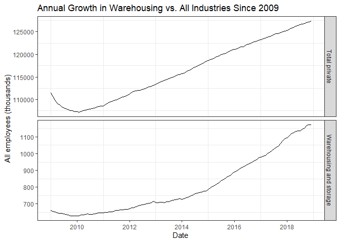

Source: BLS CES. This does not include self-employed, government, or agricultural workers.

## Warehouse work profile

We can also look at the job characteristics of warehouse work. For these, I continue to focus on the common warehousing occupations in the selected industries and return to CPS data, this time using the ASEC supplement, which is gathered in March. The supplemental questions worked refer to the previous year. As a result, the current sample goes up to 2020.

### Full-time vs. part-time

The work is mostly full-time. About 87.93% of employees were engaged in full-time work in 2019.

### Wages

A full-time warehouse worker made, on average, about $32,138.57 in 2019. This number was $14,243.41 for part-time workers.

The average hourly wage for hourly warehouse workers was $17.63. The median was slightly lower, at $15.14. As the below graph shows, pay has been rising over the years.

Note, though, that I have not calculated confidence intervals, which I think will likely be sizable, because there are few individuals in most of the cells. It would be nice to look at the wages of specific occupations within the select industries, but I do not think we have enough observations for reliable estimation. I also have not adjusted for inflation.

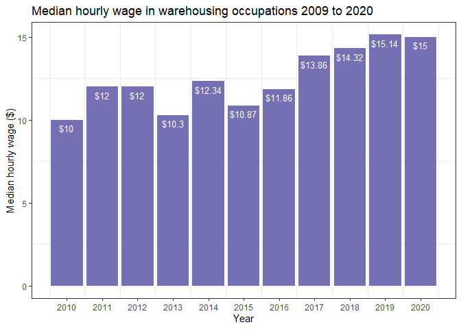

Source: IPUMS CPS. This does not include salaried, self-employed, government, or agricultural workers.

## Warehouse worker profile

### Sex

In 2019, warehouse jobs were mostly male: about 72% were held by men.

### Age

Age profile of common warehousing occupations

| Age Group | Total Employment | Share of Employment |
| --- | --- | --- |
| 16 to 19 | 16108 | 0.03 |
| 20 to 24 | 110331 | 0.20 |
| 25-54 | 357862 | 0.64 |
| 55 to 64 | 61435 | 0.11 |
| 65 years and over | 10762 | 0.02 |

### Race

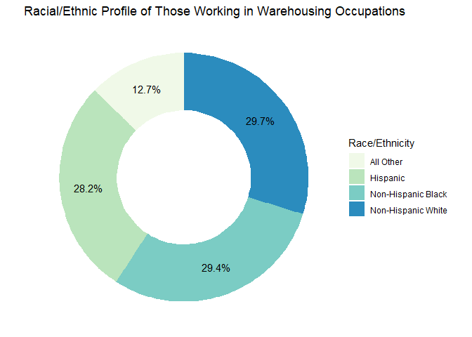

### Education

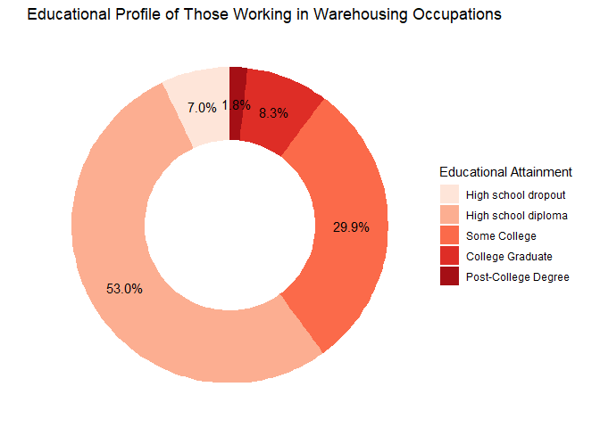

## To dos

There are more topics to investigate, including:

- Establishments
  - Number
  - Location
- Work hours